# Text Mining 01

Dasha Djukic-Min

3/13/2022

# Knowledge Mining: Text mining

# File: Lab_textmining01.R

# Theme: Download text data from web and create wordcloud

# Data: MLK speech

# Install the easypackages package

```r
### install.packages(c("easypackages","XML","wordcloud","RColorBrewer","NLP","tm","quanteda","quanteda.textstats"))
library(easypackages)
libraries("XML","wordcloud","RColorBrewer","NLP","tm","quanteda","quanteda.textstats")
```

```
## Package version: 3.2.1
## Unicode version: 13.0
## ICU version: 69.1
```

```
## Parallel computing: 8 of 8 threads used.
```

```
## See https://quanteda.io for tutorials and examples.
```

```
## All packages loaded successfully
```

# Download text data from website

```r
mlk_speech <-URLencode("http://www.analytictech.com/mb021/mlk.htm")
```

# use htmlTreeParse function to read and parse paragraphs

```r
doc.html<- htmlTreeParse(mlk_speech, useInternal=TRUE)
mlk <- unlist(xpathApply(doc.html, '//p', xmlValue))

head(mlk, 3)
```

```
## [1] "I am happy to join with you today in what will go down in\r\nhistory as the greatest demonstration for freedom in the history\r\nof our nation. "
## [2] "Five score years ago a great American in whose symbolic shadow\r\nwe stand today signed the Emancipation Proclamation. This\r\nmomentous decree came as a great beckoning light of hope to\r\nmillions of Negro slaves who had been seared in the flames of\r\nwithering injustice. It came as a joy…
## [3] "But one hundred years later the Negro is still not free. One\r\nhundred years later the life of the Negro is still sadly crippled\r\nby the manacles of segregation and the chains of discrimination. "
```

```r
words.vec <- VectorSource(mlk)
```

# Check the class of words.vec

```r
class(words.vec)
```

```
## [1] "VectorSource" "SimpleSource" "Source"
```

# Create Corpus object for preprocessing

```r
words.corpus <- Corpus(words.vec)
inspect(words.corpus)
```

```
## <<SimpleCorpus>>
## Metadata:  corpus specific: 1, document level (indexed): 0
## Content:  documents: 26
##
##  [1] I am happy to join with you today in what will go down in\r\nhistory as the greatest demonstration for freedom in the history\r\nof our nation.
##  [2] Five score years ago a great American in whose symbolic shadow\r\nwe stand today signed the Emancipation Proclamation. This\r\nmomentous decree came as a great beckoning light of hope to\r\nmillions of Negro slaves who had been seared in the flames of\r\nwithering injustice. It came as a joy…
##  [3] But one hundred years later the Negro is still not free. One\r\nhundred years later the life of the Negro is still sadly crippled\r\nby the manacles of segregation and the chains of discrimination.
##  [4] One hundred years later the Negro lives on a lonely island of\r\npoverty in the midst of a vast ocean of material prosperity.
##  [5] One hundred years later the Negro is still languishing in the\r\ncomers of American society and finds himself in exile in his own\r\nland.
##  [6] We all have come to this hallowed spot to remind America of\r\nthe fierce urgency of now. Now is the time to rise from the dark\r\nand desolate valley of segregation to the sunlit path of racial\r\njustice. Now is the time to change racial injustice to the solid\r\nrock of brotherhood. Now i…
##  [7] There will be neither rest nor tranquility in America until\r\nthe Negro is granted citizenship rights.
##  [8] We must forever conduct our struggle on the high plane of\r\ndignity and discipline. We must not allow our creative protest to\r\ndegenerate into physical violence. Again and again we must rise\r\nto the majestic heights of meeting physical force with soul\r\nforce.
##  [9] And the marvelous new militarism which has engulfed the Negro\r\ncommunity must not lead us to a distrust of all white people, for\r\nmany of our white brothers have evidenced by their presence here\r\ntoday that they have come to realize that their destiny is part\r\nof our destiny.
## [10] So even though we face the difficulties of today and tomorrow\r\nI still have a dream. It is a dream deeply rooted in the American\r\ndream.
## [11] I have a dream that one day this nation will rise up and live\r\nout the true meaning of its creed: 'We hold these truths to be\r\nself-evident; that all men are created equal."
## [12] I have a dream that one day on the red hills of Georgia the\r\nsons of former slaves and the sons of former slave owners will be\r\nable to sit together at the table of brotherhood.
## [13] I have a dream that one day even the state of Mississippi, a\r\nstate sweltering with the heat of injustice, sweltering with the\r\nheat of oppression, will be transformed into an oasis of freedom\r\nand justice.
## [14] I have a dream that little children will one day live in a\r\nnation where they will not be judged by the color of their skin\r\nbut by the content of their character.
## [15] I have a dream today.
## [16] I have a dream that one day down in Alabama, with its vicious\r\nracists, with its Governor having his lips dripping with the\r\nwords of interposition and nullification, one day right there in\r\nAlabama little black boys and black girls will be able to join\r\nhands with little white boys …
## [17] I have a dream today.
## [18] I have a dream that one day every valley shall be exalted,\r\nevery hill and mountain shall be made low, the rough places\r\nplains, and the crooked places will be made straight, and before\r\nthe Lord will be revealed, and all flesh shall see it together.
## [19] This is our hope. This is the faith that I go back to the\r\nmount with. With this faith we will be able to hew out of the\r\nmountain of despair a stone of hope. With this faith we will be\r\nable to transform the genuine discords of our nation into a\r\nbeautiful symphony of brotherhood. W…
## [20] And I say to you today my friends, let freedom ring. From the\r\nprodigious hilltops of New Hampshire, let freedom ring. From the\r\nmighty mountains of New York, let freedom ring. From the mighty\r\nAlleghenies of Pennsylvania!
## [21] Let freedom ring from the snow capped Rockies of Colorado!
## [22] Let freedom ring from the curvaceous slopes of California!
## [23] But not only there; let freedom ring from the Stone Mountain\r\nof Georgia!
## [24] Let freedom ring from Lookout Mountain in Tennessee!
## [25] Let freedom ring from every hill and molehill in Mississippi.\r\nFrom every mountainside, let freedom ring.
## [26] And when this happens, when we allow freedom to ring, when we\r\nlet it ring from every village and hamlet, from every state and\r\nevery city, we will be able to speed up that day when all of\r\nGod's children, black men and white men, Jews and Gentiles,\r\nProtestants and Catholics, will b…
```

# Turn all words to lower case

```r
words.corpus <- tm_map(words.corpus, content_transformer(tolower))
```

# Remove punctuations, numbers

```r
words.corpus <- tm_map(words.corpus, removePunctuation)
words.corpus <- tm_map(words.corpus, removeNumbers)
```

# How about stopwords, then uniform bag of words created

```r
words.corpus <- tm_map(words.corpus, removeWords, stopwords("english"))
```

# Create Term Document Matric

```r
tdm <- TermDocumentMatrix(words.corpus)
inspect(tdm)
```

```
## <<TermDocumentMatrix (terms: 260, documents: 26)>>
## Non-/sparse entries: 383/6377
## Sparsity           : 94%
## Maximal term length: 14
## Weighting          : term frequency (tf)
## Sample             :
##          Docs
## Terms     16 18 19 2 20 26 3 6 8 9
##   able     1  0  3 0  0  2 0 0 0 0
##   day      2  1  1 0  0  1 0 0 0 0
##   dream    1  1  0 0  0  0 0 0 0 0
##   every    0  2  0 0  0  3 0 0 0 0
##   freedom  0  0  1 0  3  1 0 0 0 0
##   let      0  0  0 0  3  1 0 0 0 0
##   negro    0  0  0 1  0  1 2 0 0 1
##   one      2  1  1 0  0  0 2 0 0 0
##   ring     0  0  0 0  3  2 0 1 0 0
##   today    0  0  0 1  1  0 0 0 0 1
```

```r
m <- as.matrix(tdm)
wordCounts <- rowSums(m)
wordCounts <- sort(wordCounts, decreasing=TRUE)
head(wordCounts)
```

```
## freedom     one    ring   dream     let     day
##      13      12      12      11      10       9
```

# Create Wordcloud

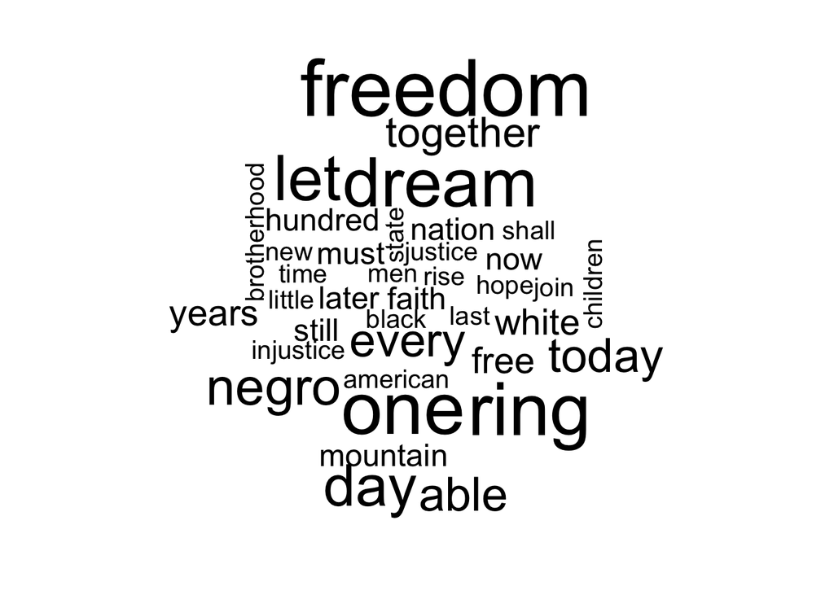

```r
cloudFrame<-data.frame(word=names(wordCounts),freq=wordCounts)

set.seed(1234)
wordcloud(cloudFrame$word,cloudFrame$freq)
```

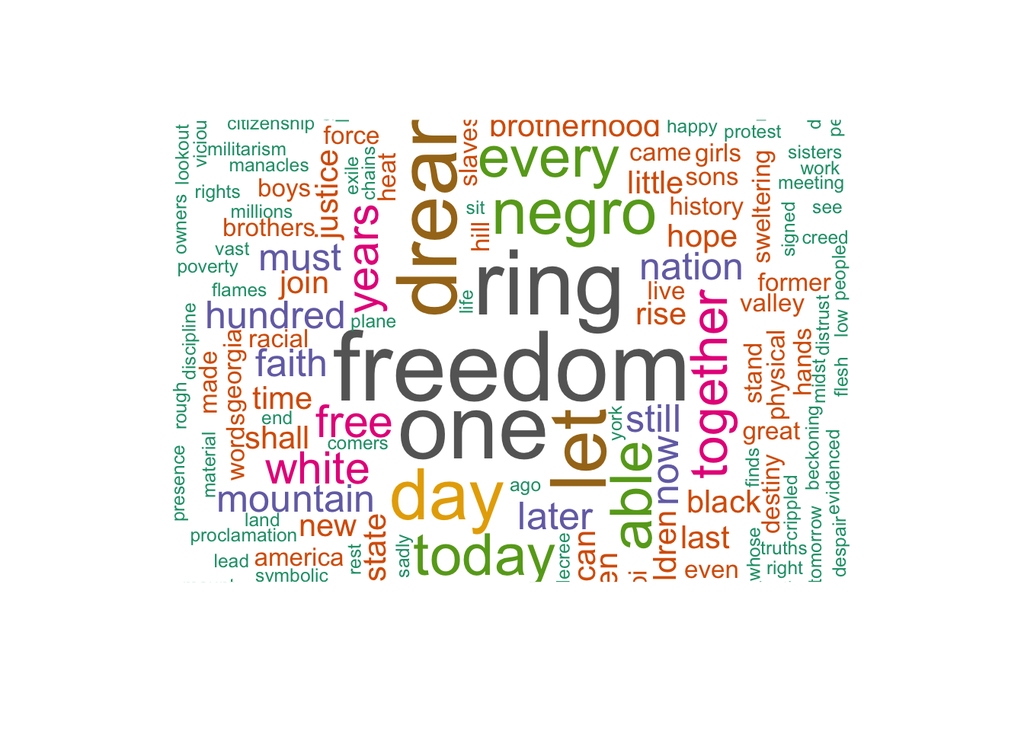

```r
wordcloud(names(wordCounts),wordCounts, min.freq=1,random.order=FALSE, max.words=200,scale=c(4,.5), rot.per=0.35,colors=brewer.pal(8,"Dark2"))
```

# N-gram with two to three words

```r
textstat_collocations(mlk, size = 2:3)
```

```
##             collocation count count_nested length      lambda           z
## 1               will be    12           12      2  6.18006777  8.52344174
## 2          freedom ring     9            9      2  6.16204416  7.86093251
## 3                i have     8            8      2  5.79950409  7.72674740
## 4                have a     9            9      2  5.30708831  7.60099495
## 5            dream that     6            6      2  5.58442352  7.07713450
## 6           let freedom     9            9      2  7.01188170  7.02799330
## 7               one day     8            8      2  6.90192349  6.87515367
## 8               a dream    10           10      2  6.25575004  6.75194436
## 9              that one     5            5      2  5.10594547  6.58004714
## 10            ring from     6            6      2  7.73858495  6.34302115
## 11              we will     5            5      2  3.86081718  6.15370386
## 12             negro is     4            4      2  4.65396035  6.11597271
## 13           from every     4            4      2  5.11785291  5.94481579
## 14              free at     3            3      2  7.12331459  5.59608371
```

[output cut: 109 more lines]

# Run the program on Winston Churchill’s Finest Hour speech?

# http://www.historyplace.com/speeches/churchill-hour.htm

# Download text data from website

```r
wc_speech <-URLencode("http://www.historyplace.com/speeches/churchill-hour.htm")
```

# Use htmlTreeParse function to read and parse paragraphs

```r
doc.html <- htmlTreeParse(wc_speech, useInternal=TRUE)
```

# Extract all the paragraphs (HTML tag is p, starting at

# the root of the document). Unlist flattens the list to

# create a character vector

```r
wc <- unlist(xpathApply(doc.html, '//p', xmlValue))
```

# Check the data; the head() function displays the first n rows present in the input data frame

# Running this command shows that each line in the text is an individual element in the vector wc

```r
head(wc, 4)
```

```
## [1] ""
## [2] ""
## [3] "\n        At 5:30 a.m. on May 10, 1940, Nazi Germany began a massive attack against\n        Holland, Belgium, Luxembourg, and France. Defending those countries were\n        soldiers of the British Expeditionary Force  along with the French, Belgian,\n        and Dutch (Allied) armies. \n  …
## [4] "  The Germans relied on an aggressive battle plan,\n        utilizing modern communications such as radio to direct troops in the field. The Allies, for their part, assumed a defensive posture, just as they had done at the start of World War I, and in many cases  still relied\n        on han…
```

# In order to create corpus, first convert the vector wc into a VectorSource

# Corpus is a complete list of all of the words that we are looking at

# There are many types of sources, but VectorSource() is made for working with character vectors in R

```r
words.vec <- VectorSource(wc)
```

# Check the class of words.vec

```r
class(words.vec)
```

```
## [1] "VectorSource" "SimpleSource" "Source"
```

# Create Corpus object for preprocessing or data cleaning

# Notice that inspecting the corpus shows the document has many characters like backslashes and quotation marks that we don’t need

```r
words.corpus <- Corpus(words.vec)
inspect(words.corpus)
```

```
## <<SimpleCorpus>>
## Metadata:  corpus specific: 1, document level (indexed): 0
## Content:  documents: 38
##
##  [1]
##  [2]
##  [3] \n        At 5:30 a.m. on May 10, 1940, Nazi Germany began a massive attack against\n        Holland, Belgium, Luxembourg, and France. Defending those countries were\n        soldiers of the British Expeditionary Force  along with the French, Belgian,\n        and Dutch (Allied) armies. \n
##  [4]   The Germans relied on an aggressive battle plan,\n        utilizing modern communications such as radio to direct troops in the field. The Allies, for their part, assumed a defensive posture, just as they had done at the start of World War I, and in many cases  still relied\n        on han…
##  [5] As a result, the German Blitzkrieg\n        (lightning attack)  caught the Allies off-guard.  German Panzer tanks staged a surprise attack through the 'impassable' Ardennes  Forest then turned northward\n        and soon surrounded the bulk of the Allied armies in Belgium. The "Miracle at Du…
##  [6] After just a few weeks of battle, Hitler's armies had conquered Holland, Luxembourg and Belgium. Paris fell on June 14th. Three days later, the French requested an armistice.
##  [7] The following day, June 18th, British Prime Minister Winston Churchill\n        spoke to the House of Commons about the disastrous turn of events in Europe amid the stark realization\n        that Britain now stood alone against the seemingly unstoppable might of Hitler's military machine.
##  [8]
##  [9] I spoke the other day of the colossal military disaster which occurred\nwhen the French High Command failed to withdraw the northern Armies from\nBelgium at the moment when they knew that the French front was decisively\nbroken at Sedan and on the Meuse. This delay entailed the loss of fifte…
## [10] I am not reciting these facts for the purpose of recrimination. That\nI judge to be utterly futile and even harmful. We cannot afford it. I recite\nthem in order to explain why it was we did not have, as we could have had,\nbetween twelve and fourteen British divisions fighting in the line i…
## [11] Of this I am quite sure, that if we open a quarrel between the past\nand the present, we shall find that we have lost the future. Therefore,\nI cannot accept the drawing of any distinctions between members of the\npresent Government. It was formed at a moment of crisis in order to unite\nall…
```

[output cut: 27 more lines]

# Turn all words to lower case; we are doing this because R is case sensitive, so two same words written

# in different cases (say, one lower-case and another one upper-case) can be interpreted as two different words

```r
words.corpus <- tm_map(words.corpus, content_transformer(tolower))
```

# Remove punctuations, numbers; this is a part of preprocessing or data cleaning

```r
words.corpus <- tm_map(words.corpus, removePunctuation)
words.corpus <- tm_map(words.corpus, removeNumbers)
```

# How about stopwords, then uniform bag of words created; this further cleans the data

# Stopwords function removes common words such as and, the, an, conjuctions (and, or, but…)

```r
words.corpus <- tm_map(words.corpus, removeWords, stopwords("english"))
```

# Inspect the newly cleaned document

```r
writeLines(as.character(words.corpus[[30]]))
```

```
##    yet know   happen  france  whether  french
## resistance   prolonged   france    french empire overseas
##  french government   throwing away great opportunities  casting
## adrift  future     continue  war  accordance
##  treaty obligations      felt able  release
##  house   read  historic declaration     desire
##  many frenchmenand    heartswe  proclaimed  willingness
##   darkest hour  french history  conclude  union  common citizenship
##   struggle however matters may go  france    french government
##   french governments    island    british empire
##  never lose  sense  comradeship   french people
##  now called upon  endure     suffering  shall emulate
##  courage   final victory rewards  toils  shall share
##  gains aye  freedom shall  restored    abate nothing
##   just demands  one jot  tittle   recede czechs poles
## norwegians dutch belgians  joined  causes
## shall  restored
```

# Stemming is another way to clean the data but it is not part of this exercise

# Create Term Document Matric, which checks the frequency of words

# All the documents will be arranged in columns and all the words will be arranged in rows

# This step transforms the document into a mathematical matrix and makes it ready for text analysis

```r
tdm <- TermDocumentMatrix(words.corpus)
inspect(tdm)
```

```
## <<TermDocumentMatrix (terms: 1178, documents: 38)>>
## Non-/sparse entries: 1948/42816
## Sparsity           : 96%
## Maximal term length: 15
## Weighting          : term frequency (tf)
## Sample             :
##          Docs
## Terms     11 14 16 17 18 20 22 25 30 9
##   air      0  0  0  1  0 13  3  0  0 0
##   battle   0  0  1  0  0  0  3  0  0 2
##   british  0  0  1  0  0  1  0  0  1 3
##   force    0  2  0  1  0  4  3  0  0 1
##   france   0  1  0  0  0  1  2  0  3 2
##   french   0  0  0  0  0  0  1  0  7 6
##   great    0  0  0  4  0  3  3  1  1 0
##   large    0  3  0  3  2  0  0  0  0 0
##   upon     0  0  0  1  0  0  0  3  1 1
##   war      1  0  2  2  1  0  1  2  1 0
```

# Check the frequency of words

```r
m <- as.matrix(tdm)
wordCounts <- rowSums(m)
wordCounts <- sort(wordCounts, decreasing=TRUE)
head(wordCounts)
```

```
##    war    air france  great french   upon
##     24     23     20     20     19     16
```

# Create Wordcloud

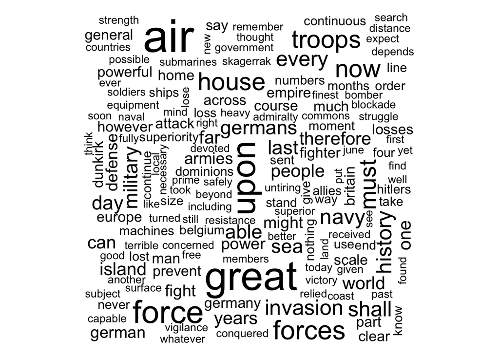

```r
cloudFrame<-data.frame(word=names(wordCounts),freq=wordCounts)
set.seed(1234)
wordcloud(cloudFrame$word,cloudFrame$freq)
```

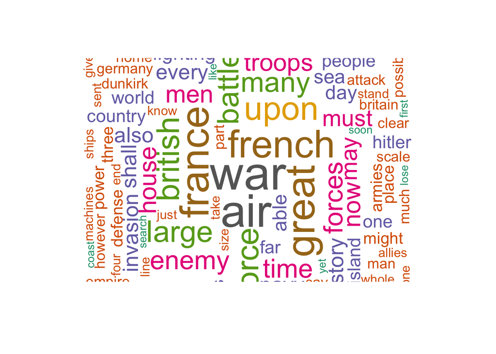

```r
wordcloud(names(wordCounts),wordCounts, min.freq=1,random.order=FALSE, max.words=200,scale=c(4,.5), rot.per=0.35,colors=brewer.pal(8,"Dark2"))
```

# N-gram with two to three words

```r
textstat_collocations(wc, size = 2:3)
```

```
##                     collocation count count_nested length      lambda
## 1                       we have    28           26      2  3.77916262
## 2                     air force     7            7      2  5.54649978
## 3                     in france    15           14      2  4.81291927
## 4                       will be     9            9      2  3.69621960
## 5                        of the    44           44      2  1.63072006
## 6                        in the    33           33      2  1.84498145
## 7                        a very     8            8      2  4.28352659
## 8                        do not     6            6      2  5.47343255
## 9                     have been     8            8      2  4.10384854
## 10                history place     4            4      2  7.23311404
## 11                     would be     6            6      2  4.23618394
## 12                    there are     5            5      2  4.79507728
## 13                   very large     4            4      2  4.97349698
## 14                    before us     3            3      2  6.08314863
```

[output cut: 1167 more lines]